# Finding Distribution Parameters of Simple Data Sets in R and TMB

Rebecca Stubbs

Tuesday, December 06, 2016

The TMB library is a link that allows the high-level, statistically-oriented programming language R to interface with the computational speed of C++ for calculating likelihood. This example walks through how to generate simple parameter estimates for different distributions using R, then Template Model Builder.

Unlike many of the function calls in R and regression and modeling packages available on CRAN, using Template Model Builder requires you to literally write out the equations to calculate your likelihood in order to run a model. As such, this page goes into the weeds of how to calculate joint negative log likelihood in R first (familiar territory), then switches to TMB in hopes that it will make the C++ versions more intelligible.

My hope is that this document can serve the foundation of an understanding of to use TMB, by starting from the ground up.

# Starting out in R

So, let’s start by getting a workspace set up: loading the required libraries, etc.

```r
rm(list=ls()) # Removing everything from the R workspace
library(TMB) # Template model builder
library(data.table) #data manipulation package
library(ggplot2) # Plotting package
library(ggthemes) # makes plots more elegant
```

## Simulating some data

First, let’s create a data set, where we know ahead of time what the distribution parameters are. This has the advantage of allowing the programmer to know ahead of time what the “right answer” for parameters should be, which will allow us to check our code for errors.

To keep things simple, we’ll start out with data sampled from a normal distribution.

```r
simulated_data<-data.table(sim_norm=rnorm(10000,50,6))
    # Generating a column witihn the data set ("sim_norm") that has 10000 observations
    # pulled from a normal distribution of mean 50, with a standard deviation of 6
```

## Likelihood overview

Let’s say for the sake of example that you *don’t* already know the distribution parameters that were used to create these data sets, and you wanted to find out. To do this, we could roughly use the following process:

- 0. Decide what distribution is appropriate (for now, we will assume we are omnipotent and just “know”)
- 1. Come up with a starting guess for what the parameters are
- 2. Evaluate how likely it is that each point could have come from that distribution
- 3. Tweak the parameters, and see whether it becomes more likley that the data was generated from that distribution
- 4. Repeat steps 2) and 3) until you reach a point of diminishing returns.

Steps 2-4 are easy to complete with the help of computers and statistical packages through functions and optimization. Our intuition would tell us that data points closer to the mean of the distribution are probably more likely to have been generated by a process with those parameters than those far away from the mean. We also know that data points further from the mean are less surprising if the data is very noisy (has a high standard deviation).

Let’s use R’s “dnorm” function to evaluate how likely it is that an individual point came from a distribution, and visualize that data point as a red line being portrayed over the distribution:

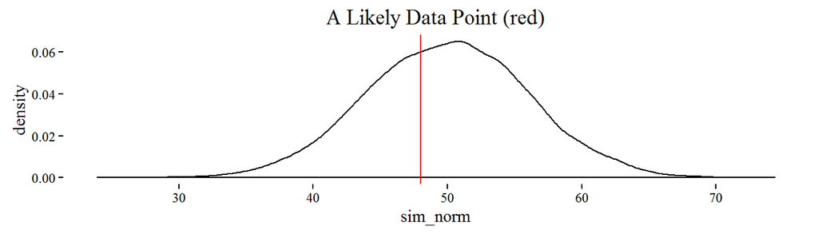

```r
# Visualizing the data point over the distribution
ggplot(data=simulated_data)+
  geom_density(aes(sim_norm))+
  geom_vline(xintercept=48,colour='red')+
  labs(title="A Likely Data Point (red)")+
  theme_tufte()
```

```r
# Discovering the likelihood of the number 48 being
# generated from a normal distribution with
# mean 50, SD 6
dnorm(48,50,6)
```

```
## [1] 0.0628972
```

Now, let’s evaluate the likelihood of a data point that seems less likely to have come from that distribution:

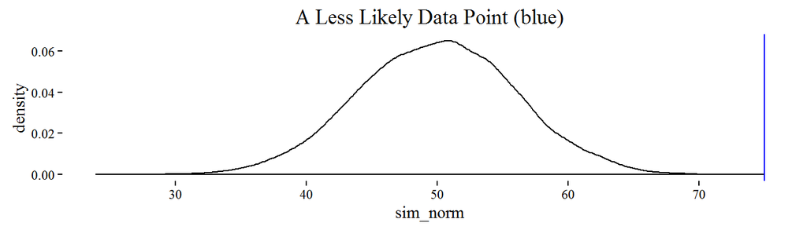

```r
ggplot(data=simulated_data)+
  geom_density(aes(sim_norm))+
  geom_vline(xintercept=75,colour='blue')+
  labs(title="A Less Likely Data Point (blue)")+theme_tufte()
```

```r
dnorm(75,50,6)
```

```
## [1] 1.129383e-05
```

As expected, the likelihood of the data point farther away from the mean is smaller. But that’s just one data point– what if you have a set of numbers that you think could have been generated from a given distribution?